# TempMunger

## A Visual Analytics Approach Supporting Transformations of Time-Oriented Data

Robert Thurnher

```python
from datetime import date

print(date.today())
```

```
2017-05-29
```

# Outline

- Motivation
- Research Questions
- State of the Art
- Requirements
- Methodological Approach
- Prototype Design
- Demo
- Evaluation
- Results
- Discussion
- Future Work
- Conclusion

# Motivation

**Visual Analytics** (VA), *"the science of analytical reasoning facilitated by interactive visual interfaces"* [Thomas and Cook, 2005], [Loukides, 2010]:

1. **Data wrangling** a.k.a. **munging**
2. Statistics & machine learning
3. Visualization & analysis itself

## Data Wrangling

... generally denotes the cumbersome task of making data useful for analysis.

- **Tedious** task
- **High-level** support
- **Time-oriented** data

$$\rightarrow \textbf{TempMunger}$$

# Research Questions

*How can we support data wrangling with VA techniques?*

## Subquestions

- *Which data transformations are best supported by analytical methods and for which transformations is visual support beneficial?*
- *How do concrete data wrangling workflow processes look like and how can these processes be supported by VA methods?*
- *What data wrangling tasks need to be tackled in particular when dealing with time-oriented data and how can we support them with VA methods?*

# State of the Art

## DataWrangler

[Kandel et al., 2011]

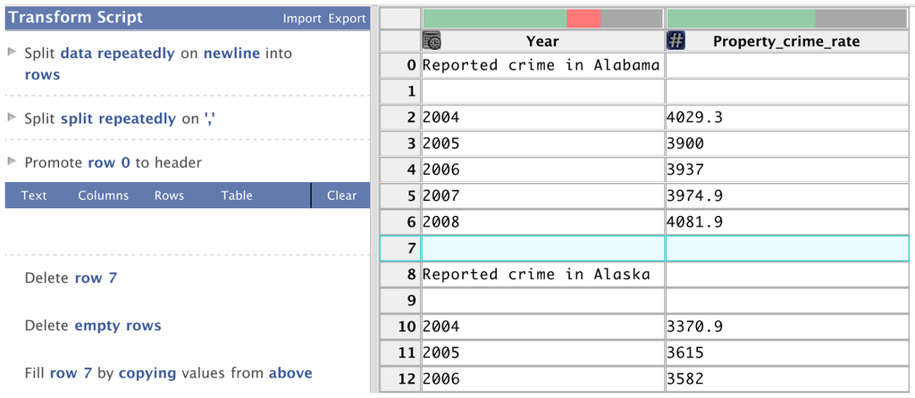

```python
from IPython.core.display import Image, display

display(Image('../thesis/figures/state-of-the-art/data-wrangler.png', width=600))
```

## OpenRefine

[openrefine.org](http://openrefine.org/)

[figure not shown]

```python
from IPython.core.display import Image, display

display(Image('../thesis/figures/state-of-the-art/google-refine.png', width=600))
```

## Kibana Timelion

[Khan, 2015]

[figure not shown]

```python
from IPython.core.display import Image, display

display(Image('../thesis/figures/state-of-the-art/kibana-timelion.png', width=600))
```

## Jupyter Notebooks

[jupyter.org](https://jupyter.org/)

[figure not shown]

```python
from IPython.core.display import Image, display

display(Image('../thesis/figures/state-of-the-art/jupyter-notebooks.png', width=500))
```

|  | *DataWrangler* | *OpenRefine* | *Timelion* | *Jupyter* |
| --- | --- | --- | --- | --- |
| Time-Oriented | No | Yes | Focus | Supported |
| Charting | Little | Some | Extensive | Extensive |
| Approach | Spreadsheet | Spreadsheet | CLI + DSL | CLI + REPL |

|  | *DataWrangler* | *OpenRefine* | *Timelion* | *Jupyter* | *TempMunger* |
| --- | --- | --- | --- | --- | --- |
| Time-Oriented | No | Yes | Focus | Supported | **Focus** |
| Charting | Little | Some | Extensive | Extensive | **Focus** |
| Approach | Spreadsheet | Spreadsheet | CLI + DSL | CLI + REPL | **Dashboard** |

# Requirements

Derived from:

- State of the art review
- Requirements analysis
- **R1:** The prototype must be capable of loading and working with diverse datasets
- **R2:** Moreover, it must be intuitive for casual users (i.e., less technically expertized)
- **R3:** Yet, some shortcuts for rather power users should be supported as well
- **R4:** Focus of our approach has to be on visual-interactive charting aid
- **R5:** These charts must be centered on applying time-oriented data transformations
- **R6:** Plus, they should provide extraordinary visual overview of the dataset at hand
- **R7:** Thus, focus has to be put on choosing most effective and efficient visualizations
- **R8:** Furthermore, interactively exploring data must be conveniently possible
- **R9:** A more traditional tabular editor should be available with direct manipulation
- **R10:** Editing time-oriented data should be supported by specific UI controls
- **R11:** Data quality issues need to be easily identifiable and effectually addressable
- **R12:** Conveniently spotting data anomalies respectively outliers should be possible
- **R13:** Concrete time-oriented data transformation operations to be supported:
  - Data cleaning regarding missing and erroneous values
  - Normalization concerning points in time and intervals
  - Merging columns in an intuitive visual-interactive way
  - Formatting cleanup, e.g., inconsistencies or conversion

# Methodological Approach

Iterative **design**, **implementation**, and **evaluation** of a software **prototype**

Nested model by [Munzner, 2009], including following steps:

- State of the art review
- Requirements analysis
- Design of interactive visualizations and UI
- Iterative prototypical implementation
- Qualitative evaluation of results

## Data–Users–Tasks Triangle

[Miksch and Aigner, 2014]

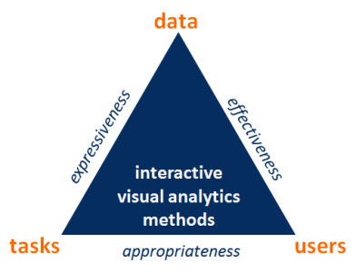

```python
from IPython.core.display import Image, display

display(Image('../thesis/figures/introduction/cvast-triangle.png', width=400))
```

$$\rightarrow \textbf{UX Personas } \text{[Cooper, 2004]}$$

# Prototype Design

## Wireframing with UI Mockups

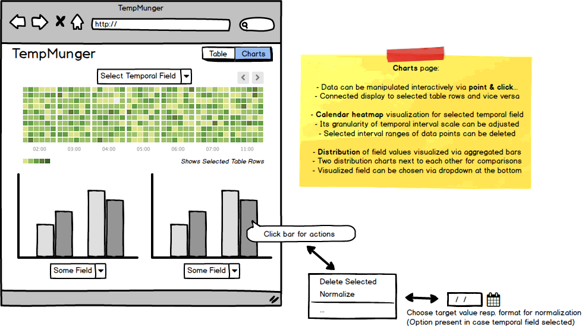

```python
from IPython.core.display import Image, display

display(Image('../thesis/figures/design/mockup-6.png', width=800))
```

## Prototyping with Agile Development

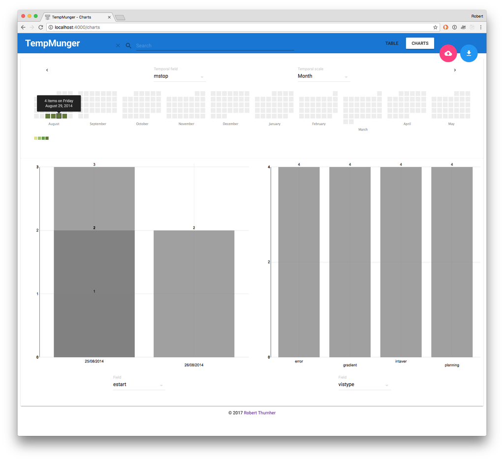

```python
from IPython.core.display import Image, display

display(Image('../thesis/figures/implementation/screenshot-charts-page.png', width=550))
```

## Developed Features

- **Transformations**
  - **Direct manipulation** via UI controls
  - **Cleaning** of missing and erroneous values
  - **Normalization** concerning: points in time & intervals
  - **Deletion** of rows
  - **Merging** of columns
  - **Formatting** cleanup
- **Outlier detection**
- **Visual overview**

## Software Architecture

[figure not shown]

```python
from IPython.core.display import Image, display

display(Image('../thesis/figures/architecture/system-overview.png', width=350))
```

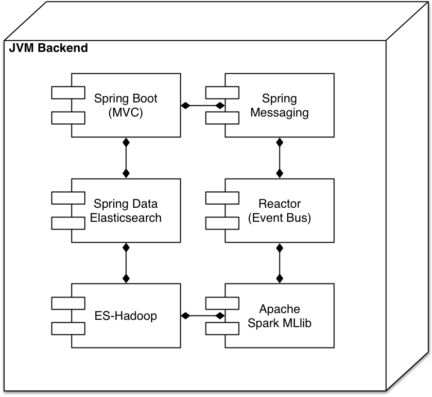

```python
from IPython.core.display import Image, display

display(Image('../thesis/figures/architecture/backend-components.png', width=400))
```

[figure not shown]

```python
from IPython.core.display import Image, display

display(Image('../thesis/figures/architecture/backend-components.png', width=400))
```

# [Demo](https://temp-munger.robi42.net/)

# Evaluation

- **Heuristic** evaluation
- User/usability **tests**

## Evaluation Study Design

### Common Setup

That is, shared by both parts of the study:

- One participant at a time
- Introductory explaining session
- 10 tasks with goals to perform
- Observal and on-demand support
- 5 interview questions at the end

#### Tasks & Goals

1. Upload a dataset using a given CSV file
2. Edit time-oriented data via table editor
3. Find potential outliers in the given dataset
4. Identify missing respectively erroneous values
5. Fill these with actual temporal values and/or delete their entries
6. Normalize all entries in a certain month, moving them to another one
7. Move all entries on a specific day to another point in time
8. Delete all entries within a certain timespan or on a certain date
9. Merge time-oriented data columns on the table editor view page
10. Export data as CSV, choosing a format for time-oriented values

#### Interview Questions

1. What is your overall impression?
2. What are the strengths of TempMunger?
3. What are the shortcomings of TempMunger?
4. Do you believe TempMunger can be useful for you?
5. If not, what do you think is needed to make it so?

### Heuristic Evaluation

- 3 usability/InfoVis **experts** [Holzinger, 2005]
- 10 classic **heuristics** according to [Nielsen, 1993]
- 3 InfoVis-specific heuristics according to [Forsell and Johansson, 2010]

#### Classic Heuristics

- Visibility of system status
- Match between system and the real world
- User control and freedom
- Consistency and standards
- Error prevention
- Recognition rather than recall
- Flexibility and efficiency of use
- Aesthetic and minimalist design
- Help users recognize, diagnose, and recover from errors
- Help and documentation

#### InfoVis Heuristics

- Information coding
- Spatial organization
- Remove the extraneous

### User Tests

- 2 **potential users**
- Same 10 tasks
- Same interview
- Focus on:
  - Impression
  - Feedback

$$\rightarrow \text{Potentially revealing other aspects due to different perspective}$$

# Results

Our approach and prototype proved to be generally **useful** and **viable**.

- *"Good overview"*
- *"Can be easily done"*
- *"It does what it’s supposed to do"*

## Strengths

- **Good** visually interactive overview offered with charting aid
- **Smoothness** regarding UX
- **Pleasentness** of general design
- **Quality** of present visualizations

## Weaknesses

... mainly relating to **incompleteness** of supported transformation operations and visualizations.

### Heuristic Categories

ordered by frequency descending:

1. *Information coding*
2. *User control and freedom*
3. *Spatial organization* + *flexibility and efficiency of use*

### Exemplary Found Issues

again, ordered by frequency descending:

1. Insufficient immediate and intuitive **visual feedback** regarding performed actions, e.g., on missing values cleanup (→ *visibility of system status*)
2. **Findability** of modal dialogs for missing values cleanup and interval-based normalization is suboptimal (→ *spatial organization*)
3. **Separation** of the two normalization dialogs as well as connected semantics are not intuitive and could be refined (→ *consistency and standards*)

# Discussion

## Open Issues

- The usage and behavior of the software is not always intuitive
- Immediate visual feedback of system state is partially lacking
- Sometimes possible actions are not completely clear to the user
- Generally, usability can be improved in some parts of the prototype
- Moreover, interactive chart visualizations can be further augmented
- Scalability of visualizations should be addressed more
- The supported transformation operations could be enhanced
- Some aspects are either incomplete or could, at least, be refined

## Answers to Research Questions

*Which data transformations are best supported by analytical methods and for which transformations is visual support beneficial?*

- In our case:
  - Cleanup of missing and erroneous values, allowing fill and deletion
  - Normalization of values regarding points in time and intervals
  - Merging of time-oriented data columns, using average calculations
- More generally:
  - When statistics are involved
  - Whenever batched or whole dataset
  - Fully automated when rather straightforward

*How do concrete data wrangling workflow processes look like and how can these processes be supported by VA methods?*

- Such processes are oftentimes of exploratory nature
- Thus, we are supporting them visual-interactively
- Plus, especially repetitive actions are well suited

Instead of fiddling around with the data manually,  
applying hand-crafted scripts, mainly tapping in the dark:

→ Clear **overview** plus transformation **suggestions** are conveniently **presented** and at the **fingertips**.

*What data wrangling tasks need to be tackled in particular when dealing with time-oriented data and how can we support them with VA methods?*

- Directly editing single values
- Deleting rows, also in batches
- Unifying temporal formats
- Cleaning up missing and erroneous values
- Spotting anomalies respectively outliers
- Transforming values of certain fields batch-wise
- Possibly “normalizing” these to some other specified value
- Merging columns according to some algorithm

*How can we support data wrangling with VA techniques?*

- By focusing on tasks which are:
  - Related to **batched** data transformation operations
  - As well as of rather **complex** nature

→ Requiring special attention and oversight.

These are tasks where fully automated approaches fall short, comparatively.

→ Human empowered through VA techniques can, still, perform better.

# Future Work

- Refining and adding transformations
- Addressing scalability issues of visualizations
- Enabling undo and easy repetition of operations
- Emphasizing more and, thus, enhancing the inference aspect
- Taking care of data types other than time-oriented as well

# Conclusion

The **sweet spot** is most probably located somewhere in between:

Augmenting an **interactive interface**  
driven by **powerful visualizations**  
with **semi-automatic suggestions**,  
reasonably.

- **[Thomas and Cook, 2005]** James J Thomas and Kristin A Cook. *Illuminating the Path: The Research and Development Agenda for Visual Analytics*. IEEE Computer Society, 2005.
- **[Loukides, 2010]** Mike Loukides. What is Data Science? O’Reilly Media, June 2010. https://www.oreilly.com/ideas/what-is-data-science, Accessed: 2017-04-11.
- **[Kandel et al., 2011]** Sean Kandel, Andreas Paepcke, Joseph Hellerstein, and Jeffrey Heer. Wrangler: Interactive Visual Specification of Data Transformation Scripts. In *Proceedings of the SIGCHI Conference on Human Factors in Computing Systems*, CHI ’11, pages 3363–3372, New York, NY, USA, 2011. ACM.
- **[Khan, 2015]** Rashid Khan. Timelion: The Time Series Composer for Kibana. Elastic, November 2015. https://www.elastic.co/blog/timelion-timeline, Accessed: 2017-04-11.
- **[Munzner, 2009]** Tamara Munzner. A Nested Model for Visualization Design and Validation. *IEEE Transactions on Visualization and Computer Graphics*, 15(6):921–928, November 2009.
- **[Miksch and Aigner, 2014]** Silvia Miksch and Wolfgang Aigner. Special Section on Visual Analytics: A Matter of Time: Applying a Data–Users–Tasks Design Triangle to Visual Analytics of Time-Oriented Data. *Computer & Graphics*, 38:286–290, February 2014.
- **[Cooper, 2004]** Alan Cooper. *The Inmates Are Running the Asylum*. Sams - Pearson Education, 2nd edition, 2004.
- **[Holzinger, 2005]** Andreas Holzinger. Usability Engineering Methods for Software Developers. *Communications of the ACM*, 48(1):71–74, January 2005.
- **[Nielsen, 1993]** Jakob Nielsen. *Usability Engineering*. Morgan Kaufmann, 1993.
- **[Forsell and Johansson, 2010]** Camilla Forsell and Jimmy Johansson. An Heuristic Set for Evaluation in Information Visualization. *AVI ’10 Proceedings of the International Conference on Advanced Visual Interfaces*, 10(3):199–206, 2010.